# The Effect of Events on Discussion in the Australian Federal Parliament (1901–2017)

24 October 2018

## Summary

## Approach

- Create a dataset of what was said in the Australian Federal Parliament from 1901 through to 2017 based on available public records.
- Use a correlated topic model to reduce dimemsionality.
- Analyse the effect of various events using a Bayesian hierarchical Dirichlet model.

## Data

## Hansard

- A daily text record called Hansard of what was said in the Australian Federal Parliament has been made available since it was established in 1901. It's not vertatim, but it's pretty close.
- Hansard records have been used in other counties but not really at scale in Australia (although others are also starting to use them).
- Daily PDFs are available Hansard records available online as PDFs and these are considered the official release.
- There are 14,551 days of publicly available Hansard records across both chambers of the Australian Federal Parliament.

## Example PDF page

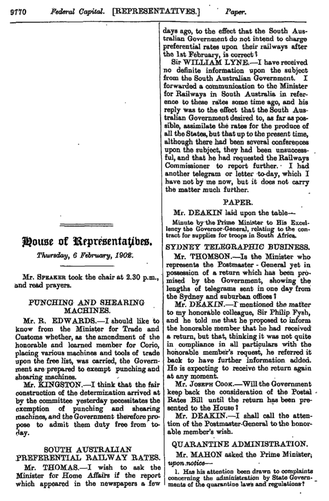

## PDF parsing

- We use scripts written in R to convert the PDFs into daily text records.
- Some error is introduced at this stage:
  - because many of the records are in a two-column format that need to be separated; and
  - the PDF parsing is not always accurate especially for older records e.g. 'the' is often parsed as 'thc'.
- We remove numbers and punctuation; change the words to lower case; and concatenate multi-word names titles and phrases, such as new zealand to new_zealand. Then the sentences are de-constructed and each word considered individually.

## Topic Model

## Latent Dirichlet Allocation - Overview

- Each document is assumed to be from a speaker who decides the topics they would like to talk about in that document, and then choose words, 'terms', that are appropriate to those topics.
- A topic could be thought of as a collection of terms, and a document as a collection of topics, where these collections are defined by probability distributions.
- The topics are not specified *ex ante*; they are an outcome of the method – this is an unsupervised machine learning method.

## Latent Dirichlet Allocation - Topic distribution for documents

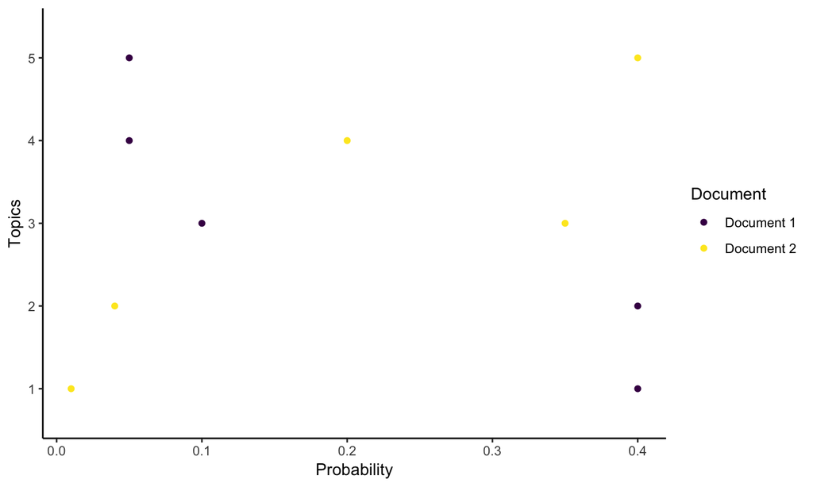

## Latent Dirichlet Allocation - Term distribution over topics

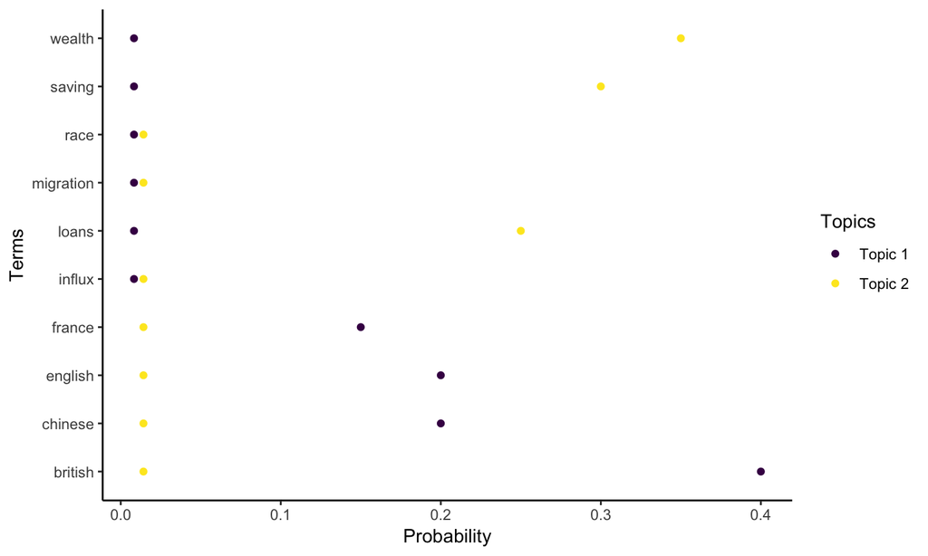

## Latent Dirichlet Allocation - Data generation process

1. There are \(K\) topics and the vocabulary consists of \(V\) terms. For each topic, decide the terms by randomly drawing distributions over the terms. The distribution over the terms for the \(k\)th topic is \(\beta_k\). Use the Dirichlet distribution with hyper-parameter \(\boldsymbol{\eta}\): \(\beta_k \sim \mbox{Dirichlet}(\boldsymbol{\eta})\), where \(\boldsymbol{\eta} = (\eta_1, \eta_2, \dots, \eta_{K})\).

## Latent Dirichlet Allocation - Data generation process (cont.)

1. Decide the topics that each document will cover by randomly drawing distributions over the \(K\) topics for each of the \(D\) documents. The topic distributions for the \(d\)th document are \(\theta_d\), and \(\theta_{d,k}\) is the topic distribution for topic \(k\) in document \(d\). Again, the Dirichlet distribution with the hyper-parameter \(0<\alpha<1\) is used here because usually a document would only cover a handful of topics: \(\theta_d \sim \mbox{Dirichlet}(\boldsymbol{\alpha})\).

## Latent Dirichlet Allocation - Data generation process (cont.)

1. If there are \(N\) terms in the \(d\)th document, then to choose the \(n\)th term, \(w_{d, n}\):
   1. Randomly choose a topic for that term \(n\), in that document \(d\), \(z_{d,n}\), from the multinomial distribution over topics in that document, \(z_{d,n} \sim \mbox{Multinomial}(\theta_d)\).
   2. Randomly choose a term from the relevant multinomial distribution over the terms for that topic, \(w_{d,n} \sim \mbox{Multinomial}(\beta_{z_{d,n}})\).

## Latent Dirichlet Allocation - Data generation process (cont.)

Given this set-up, we have a joint distribution for the variables and the analysis problem, discussed next, is to compute a posterior over \(\beta_{1:K}\) and \(\theta_{1:D}\), given \(w_{1:D, 1:N}\). This is intractable directly, but can be approximated.

## Latent Dirichlet Allocation - Analysis problem

- After the documents are created, they are all that we have to analyse. The term usage in each document, \(w_{1:D, 1:N}\), is observed, but the topics are hidden, or 'latent'.
- We do not know the topics of each document, nor how terms defined the topics. In a sense we are trying to reverse the document generation process.
- If the earlier process around how the documents were generated is assumed and we observe the terms in each document, then we can obtain estimates of the topics.

## Latent Dirichlet Allocation - Analysis problem (cont.)

- The outcomes of the LDA process are probability distributions and these define the topics. Each term will be given a probability of being a member of a particular topic, and each document will be given a probability of being about a particular topic.
- That is, we are trying to calculate the posterior distribution of the topics given the terms observed in each document.
- The choice of the number of topics, *k*, drives the results and must be specified *a priori*.

## Correlated Topic Model

Modification of LDA - rather than assuming that the distribution of topics in a document, \(\theta_d\), are a draw from a Dirichlet distribution, as in step 2 in LDA above, CTM assumes \[\theta_d \sim \mbox{Logistic Normal}(\mu, \Sigma)\] Essentially it swaps the Dirichlet for the Logistic Multivariate Normal. This sounds easy, but it's hard to implement.

## Correlated Topic Model - Example output

[figure not shown]

## Structural Topic Model

The Structural Topic Model approach then adds a covariate to \(\mu\) which allows consideration of additional information. \[\theta_d|X_d\gamma\Sigma \sim \mbox{Logistic Normal}(\mu = X_d\gamma, \Sigma)\] Again, sounds easy, but hard to implement, and they have a very nice solutions algorithm.

## Why not use STM?

STM is great, but it is specific to various contexts and ours is slightly outside them:

- No way to specify more complicated auto-correlated functional forms of the effects of events over time.
- There is no way to implement partial pooling across groups of similar documents.
- There is no way of identifying 'outlying' topic distributions – and therefore events that had an important effect – without pre-specifying the event of interest in the model. In an ideal world we could modify the STM code, but instead we build a similar, but different, analysis model.

## Analysis model

## Analysis model - Overview

- We use the estimated topic distributions from the CTM described in the previous section as an input into a Bayesian hierarchical Dirichlet regression framework.
- This relates the proportions of each topic to underlying time trends, changes in governments and elections.
- This set-up also allows us to identify 'outlying' topic distributions and relate these to other events.

## Analysis model - Set-up

- Define \(\theta_{dp}\) to be the proportion of topic of topic \(p\) on day \(d\). Note that the \(\theta_{d,1:P}\) for \(p = 1,2,\dots P=40\) are equal to the estimated values of \(\theta_d\) from the CTM.
- We assume that the majority of variation in topics is across sitting periods \(s\), where a sitting period is defined as any group of days that are less than one week apart. Using this definition, there are a total of 745 sitting periods over the period 1901 to 2017 inclusive.

## Analysis model - Daily distribution

The topic proportions on day \(d\) are modelled in reference to their membership of a particular sitting period \(s\). Firstly, we assume that each distribution of topics, \(\theta_{d,1:P}\) for each day is a draw from a Dirichlet distribution with mean parameter \(\mu_{s[d],1:P}\):

\[ \theta_{d,1:P} \sim \mbox{Dirichlet}(\mu_{s[d],1:P}) \]

The goal of the model is to relate these proportions to government \(g\) at time \(d\), and also the days since the most recent election, \(e\), while account for underlying time trends.

## Analysis model - Mean parameters

The mean parameters \(\mu_{s,p}\) are modelled on the log scale as: \[ \log \mu_{s,p} = \alpha_{g[s],p} + \cdot\alpha_{e[s],d,p} + \sum_{k=1}^{K} \beta_{p,k} \cdot x_{s,k} + \delta_{s,p} \]

- \(\alpha_{g[s],p}\) is the mean effect for government \(g\) (which covers sitting period \(s\)) and topic \(p\);
- \(\alpha_{e[s],d,p}\) is the effect of election \(e\) (which occurs in sitting period \(s\)) for topic \(p\) on day \(d\) since the election;
- \(\sum_{k=1}^{K} \beta_{p,k} \cdot x_{s,k}\) is the underlying time trend, modelled using splines: \(x_{s,k}\) is the \(k\)th basis spline in sitting period \(s\) and \(\beta_{p,k}\) is a coefficient on the \(k\)th basis spline; and
- \(\delta_{s,p}\) is a structured random, or levels, effect for each sitting period and topic.

## Analysis model - Government effects

The government term \(\alpha_{g[s],p}\) assumes there is some underlying mean effect of each government on the topic distribution. We place uninformative priors on each of these parameters: \(\alpha_{g[s],p} \sim \mbox{Normal}(0, 100)\)

## Analysis model - Election effects

The election term \(\alpha_{e[s],d,p}\) assumes there is an initial effect of an election on the topic distribution, which then decays as a function of days since election, \(d\). In particular, we model this as an AR(1) in \(d\): \[ \alpha_{e[s],d,p} = \rho_{e[s],p} \cdot \alpha_{e[s],d-1,p} \]

We use non-informative priors.

## Analysis model - Time effects

We model the underlying time trend in topics using splines regression. The intuition behind this term is to capture the underlying non-linear trend in topic distributions over time, which is caused by large-scale structural changes in the economy, and Australian society and culture. The \(x_{s,k}\) for \(k = 1,2,\dots, K\) are the value of cubic basis splines for sitting period \(s\) at knot point \(k\). We place knot points every five sitting periods as this is the average length of time for a government to sit.

## Analysis model - Sitting period effects

The sitting period-specific random effect \(\delta_{s,p}\) allows the topic distributions in some sitting periods to be different than expected based on government and election effects: \[ \delta_{s,p} \sim \mbox{Normal}(0, \sigma_{e[s],p}^2) \]

The variance parameters \(\sigma_{e[s],p}^2\) give an indication of the how the variation in topics is changing over election periods. If the estimates of the variance are larger, then there is more variation in the topics discussed within an election period. Non-informative priors are placed on the variance parameters: \[ \sigma_{e[s],p} \sim \mbox{Uniform}(0,3) \]

## Results

## Topic modelling

We choose 40 topics because it is the minimum needed to have meaningful results.

| topic | terms |
| --- | --- |
| 2 | constitution, parliament, rights, powers, constitutional |
| 4 | bank, money, country, per_cent, budget |
| 6 | tax, income, taxation, treasurer, per_cent |
| 8 | department, service, officers, office, estimates |
| 10 | court, law, royal, evidence, attorneygeneral |
| 12 | war, defence, country, ill, soldiers |

## Analysis model - Estimates by sitting period

[figure not shown]

## Analysis model - Significantly different elections

| Number | Year | Date | Total seats | Election winner |
| --- | --- | --- | --- | --- |
| 19 | 1949 | 1949-12-10 | 121 | Non-labor |
| 28 | 1972 | 1972-12-02 | 125 | Labor |
| 29 | 1974 | 1974-05-18 | 127 | Labor |
| 30 | 1975 | 1975-12-13 | 127 | Non-labor |
| 32 | 1980 | 1980-10-18 | 125 | Non-labor |
| 33 | 1983 | 1983-03-05 | 125 | Labor |
| 36 | 1990 | 1990-03-24 | 148 | Labor |
| 38 | 1996 | 1996-03-02 | 148 | Non-labor |
| 39 | 1998 | 1998-10-03 | 148 | Non-labor |
| 41 | 2004 | 2004-10-09 | 150 | Non-labor |
| 42 | 2007 | 2007-11-24 | 150 | Labor |
| 44 | 2013 | 2013-09-07 | 150 | Non-labor |

## Analysis model - Significantly different governments

| Number | Government | Start | End |
| --- | --- | --- | --- |
| 12 | Bruce | 1923-02-09 | 1929-10-22 |
| 15 | Page | 1939-04-07 | 1939-04-26 |
| 16 | Menzies 1 | 1939-04-26 | 1941-08-28 |
| 21 | Menzies 2 | 1949-12-19 | 1966-01-26 |
| 22 | Holt | 1966-01-26 | 1967-12-19 |
| 25 | McMahon | 1971-03-10 | 1972-12-05 |
| 26 | Whitlam | 1972-12-05 | 1975-11-11 |
| 27 | Fraser | 1975-11-11 | 1983-03-11 |
| 28 | Hawke | 1983-03-11 | 1991-12-20 |
| 30 | Howard | 1996-03-11 | 2007-12-03 |
| 31 | Rudd 1 | 2007-12-03 | 2010-06-24 |
| 32 | Gillard | 2010-06-24 | 2013-06-27 |

## Analysis model - All governments

[figure not shown]

## Analysis model - All elections

[figure not shown]

## Analysis model - Events

Days that were significantly different to other days in their sitting period

| date |
| --- |
| 1905-07-26 |
| 1906-08-03 |
| 1913-11-06 |
| 1918-11-26 |
| 1918-11-29 |
| 1928-08-29 |
| 1931-06-11 |
| 1945-02-21 |
| 1945-03-01 |
| 1961-09-07 |
| 1965-10-01 |
| 1970-09-18 |
| 1974-09-17 |
| 1981-08-18 |
| 1982-08-17 |
| 1986-02-11 |
| 2001-09-17 |
| 2002-10-14 |
| 2007-09-18 |
| 2010-02-25 |

## Menzies-Holt

[figure not shown]

## Whitlam stability

[figure not shown]

## Howard instability

[figure not shown]

## Issues/tradeoffs

## Issues/tradeoffs

- Even after cleaning the dataset remains imperfect and is more fit-for-purpose than of broad applicability.
- Topic interpretation is difficult.
- Inputs have to be fine-tuned.
- Assuming government effects are is constant across the whole period.
- Assuming the effect of elections is monotonically decreasing across days since election.
- Identification of unusual periods could also be improved.
- Propogation of uncertainty is inappropriate.

## Future work

## Future work

- Group identity: which is more important?

## Questions?

- rohan.alexander@anu.edu.au
- @RohanAlexander
- rohanalexander.com